**Econometrics: Methods and Applications** Erasmus University Rotterdam https://www.coursera.org/learn/erasmus-econometrics/home/welcome

# Training Exercise 1.1

> Dataset TrainExer11 contains survey outcomes of a travel agency that wishes to improve recommendation strategies for its clients. The dataset contains 26 observations on age and average daily expenditures during holidays.

```python
import numpy as np
import pandas as pd
from sklearn.linear_model import LinearRegression
import matplotlib.pyplot as plt
```

- https://pandas.pydata.org/docs/reference/api/pandas.read_csv.html
- https://pandas.pydata.org/docs/getting_started/intro_tutorials/03_subset_data.html
- https://numpy.org/doc/stable/reference/generated/numpy.reshape.html
- https://numpy.org/doc/stable/user/basics.creation.html
- https://scikit-learn.org/stable/modules/generated/sklearn.linear_model.LinearRegression.html
- https://matplotlib.org/stable/gallery/statistics/hist.html

```python
TrainExer11_pd = pd.read_csv('TrainExer11.txt', sep='\t', header=0, index_col=0)
```

```python
TrainExer11_pd.head()
```

| Observ. | Age | Expenditures |
| --- | --- | --- |
| 1 | 49 | 95 |
| 2 | 15 | 104 |
| 3 | 43 | 91 |
| 4 | 45 | 98 |
| 5 | 40 | 94 |

```python
X = pd.Series.to_numpy(TrainExer11_pd['Age']).reshape((-1, 1))
```

```python
y = pd.Series.to_numpy(TrainExer11_pd['Expenditures'])
```

## (a)

> **(a)** Make two histograms, one of expenditures and the other of age. Make also a scatter diagram with expenditures on the vertical axis versus age on the horizontal axis.

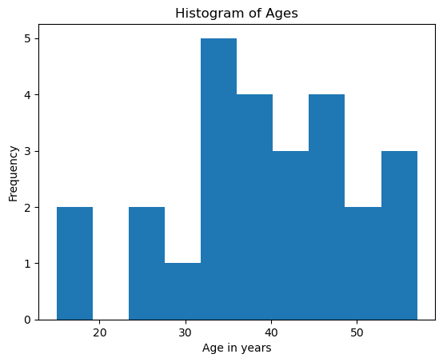

```python
plt.hist(X)
plt.xlabel('Age in years')
plt.ylabel('Frequency')
plt.title('Histogram of Ages')
```

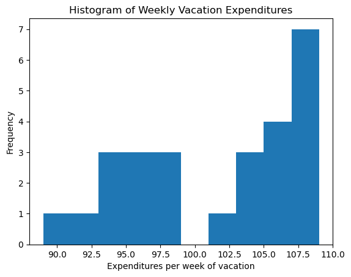

```python
plt.hist(y)
plt.xlabel('Expenditures per week of vacation')
plt.ylabel('Frequency')
plt.title('Histogram of Weekly Vacation Expenditures')
```

```python
model = LinearRegression().fit(X, y)
```

```python
r_sq = model.score(X, y)
```

```python
r_sq
```

```
0.33766820038768774
```

```python
model.intercept_
```

```
114.24110795493158
```

```python
model.coef_
```

```
array([-0.3335961])
```

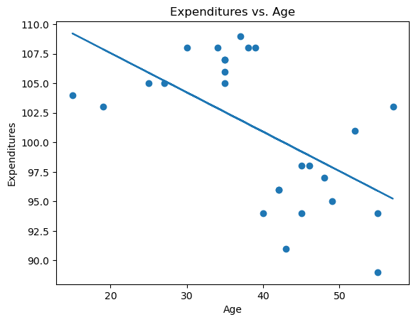

```python
plt.scatter(X,y)
plt.plot(X, model.predict(X))
plt.xlabel('Age')
plt.ylabel('Expenditures')
plt.title('Expenditures vs. Age')
```

## (c)

> **(c)** Propose a method to analyze these data in a way that assists the travel agent in making recommendations to future clients.

Separate the observations into two clusters - namely, the "top left" and the "bottom right".

Those individual clusters appear to have positive regression slopes, while the dataset - the union of the two clusters - has a negative regression slope.

## (d)

> The scatter diagram indicates two groups of clients. Younger clients spend more than older ones. Further, expenditures tend to increase with age for younger clients, whereas the pattern is less clear for older clients.

> **(d)** Compute the sample mean of expenditures of all 26 clients.

```python
np.mean(y)
```

```
101.11538461538461
```

## (e)

> **(e)** Compute two sample means of expenditures, one for clients of age forty or more and the other for clients of age below forty.

```python
A = TrainExer11_pd[(TrainExer11_pd['Age'] <= 45) & (TrainExer11_pd['Expenditures'] >= 100)]
```

```python
B = TrainExer11_pd[(TrainExer11_pd['Age'] > 45) | (TrainExer11_pd['Expenditures'] < 100)]
```

```python
X_A = pd.Series.to_numpy(A['Age']).reshape((-1, 1))
y_A = pd.Series.to_numpy(A['Expenditures'])
```

```python
len(A)
```

```
13
```

```python
X_B = pd.Series.to_numpy(B['Age']).reshape((-1, 1))
y_B = pd.Series.to_numpy(B['Expenditures'])
```

```python
len(B)
```

```
13
```

```python
np.mean(y_A)
```

```
106.38461538461539
```

```python
np.mean(y_B)
```

```
95.84615384615384
```

```python
model_A = LinearRegression().fit(X_A, y_A)
```

```python
model_B = LinearRegression().fit(X_B, y_B)
```

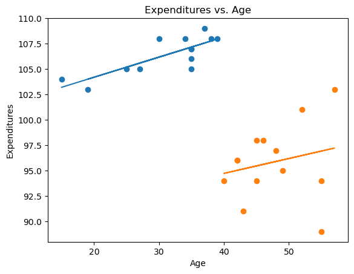

```python
plt.scatter(X_A, y_A)
plt.plot(X_A, model_A.predict(X_A))
plt.scatter(X_B, y_B)
plt.plot(X_B, model_B.predict(X_B))
plt.xlabel('Age')
plt.ylabel('Expenditures')
plt.title('Expenditures vs. Age')
```

## (f)

> **(f)** What daily expenditures would you predict for a new client of fifty years old? And for someone who is twenty-five years old?

```python
model_A.predict(np.array([25,]).reshape((-1,1)))
```

```
array([105.18155915])
```

```python
model_B.predict(np.array([50,]).reshape((-1,1)))
```

```
array([96.19543044])
```